# Introduction to Computer Vision: Plant Seedlings Classification

## Problem Statement

### Context

In recent times, the field of agriculture has been in urgent need of modernizing, since the amount of manual work people need to put in to check if plants are growing correctly is still highly extensive. Despite several advances in agricultural technology, people working in the agricultural industry still need to have the ability to sort and recognize different plants and weeds, which takes a lot of time and effort in the long term. The potential is ripe for this trillion-dollar industry to be greatly impacted by technological innovations that cut down on the requirement for manual labor, and this is where Artificial Intelligence can actually benefit the workers in this field, as **the time and energy required to identify plant seedlings will be greatly shortened by the use of AI and Deep Learning.** The ability to do so far more efficiently and even more effectively than experienced manual labor, could lead to better crop yields, the freeing up of human inolvement for higher-order agricultural decision making, and in the long term will result in more sustainable environmental practices in agriculture as well.

### Objective

The aim of this project is to Build a Convolutional Neural Network to classify plant seedlings into their respective categories.

### Data Dictionary

The Aarhus University Signal Processing group, in collaboration with the University of Southern Denmark, has recently released a dataset containing **images of unique plants belonging to 12 different species.**

- The dataset can be download from Olympus.
- The data file names are:
  - images.npy
  - Labels.csv
- Due to the large volume of data, the images were converted to the images.npy file and the labels are also put into Labels.csv, so that you can work on the data/project seamlessly without having to worry about the high data volume.
- The goal of the project is to create a classifier capable of determining a plant's species from an image.

**List of Species**

- Black-grass
- Charlock
- Cleavers
- Common Chickweed
- Common Wheat
- Fat Hen
- Loose Silky-bent
- Maize
- Scentless Mayweed
- Shepherds Purse
- Small-flowered Cranesbill
- Sugar beet

### **Note: Please use GPU runtime on Google Colab to execute the code faster.**

## Importing necessary libraries

```python
# Installing the libraries with the specified version.
# uncomment and run the following line if Google Colab is being used

!pip install tensorflow==2.17.0 scikit-learn==1.3.2 seaborn==0.13.1 matplotlib==3.8.0 numpy==1.25.2 pandas==2.2.2 opencv-python==4.8.0.76 -q --user --no-warn-script-location
```

```
   ━━━━━━━━━━━━━━━━━━━━━━━━━━━━━━━━━━━━━━━━ 10.9/10.9 MB 32.5 MB/s eta 0:00:00
```

```python
# Installing the libraries with the specified version.
# uncomment and run the following lines if Jupyter Notebook is being used
# !pip install tensorflow==2.17.0 scikit-learn==1.3.1 seaborn==0.13.1 matplotlib==3.8.0 numpy==1.25.2 pandas==2.2.2 opencv-python==4.8.0.76 -q --user --no-warn-script-location
```

**Note**: *After running the above cell, kindly restart the notebook kernel and run all cells sequentially from the start again.*

```python
import os
import numpy as np                                                                               # Importing numpy for Matrix Operations
import pandas as pd                                                                              # Importing pandas to read CSV files
import matplotlib.pyplot as plt                                                                  # Importting matplotlib for Plotting and visualizing images
import math                                                                                      # Importing math module to perform mathematical operations
import cv2                                                                                       # Importing openCV for image processing
import seaborn as sns                                                                            # Importing seaborn to plot graphs

# Tensorflow modules
import tensorflow as tf
from tensorflow.keras.preprocessing.image import ImageDataGenerator                              # Importing the ImageDataGenerator for data augmentation
from tensorflow.keras.models import Sequential                                                   # Importing the sequential module to define a sequential model
from tensorflow.keras.layers import Dense,Dropout,Flatten,Conv2D,MaxPooling2D,BatchNormalization # Defining all the layers to build our CNN Model
from tensorflow.keras.optimizers import Adam,SGD                                                 # Importing the optimizers which can be used in our model
from tensorflow.keras import backend                                                             # Importing the backend for clearing session
from sklearn import preprocessing                                                                # Importing the preprocessing module to preprocess the data
from sklearn.model_selection import train_test_split                                             # Importing train_test_split function to split the data into train and test
from sklearn.metrics import confusion_matrix                                                     # Importing confusion_matrix to plot the confusion matrix
from sklearn.preprocessing import LabelBinarizer

# Display images using OpenCV
from google.colab.patches import cv2_imshow                                                      # Importing cv2_imshow from google.patches to display images
from sklearn.model_selection import train_test_split
from tensorflow.keras import backend
from keras.callbacks import ReduceLROnPlateau
import random

# Ignore warnings
import warnings
warnings.filterwarnings('ignore')
```

## Loading the dataset

```python
# Uncomment and run the below code if you are using google colab

from google.colab import drive
drive.mount('/content/drive')
```

```python
# Load the image file of dataset
images = np.load('/content/drive/MyDrive/PGP-AIML/Computer Vision/Project/images.npy')

# Load the labels file of dataset
labels = pd.read_csv('/content/drive/MyDrive/PGP-AIML/Computer Vision/Project/Labels.csv')
```

## Data Overview

### Understand the shape of the dataset

```python
print(images.shape)
print(labels.shape)
```

```
(4750, 128, 128, 3)
(4750, 1)
```

## Exploratory Data Analysis

- EDA is an important part of any project involving data.
- It is important to investigate and understand the data better before building a model with it.
- A few questions have been mentioned below which will help you understand the data better.
- A thorough analysis of the data, in addition to the questions mentioned below, should be done.
1. How are these different category plant images different from each other?
2. Is the dataset provided an imbalance? (Check with using bar plots)

### Plotting random images from each of the class

```python
def plot_images(images,labels):
  num_classes=10                                                                  # Number of Classes
  categories=np.unique(labels)
  keys=dict(labels['Label'])                                                      # Obtaing the unique classes from y_train
  rows = 3                                                                        # Defining number of rows=3
  cols = 4                                                                        # Defining number of columns=4
  fig = plt.figure(figsize=(10, 8))                                               # Defining the figure size to 10x8
  for i in range(cols):
      for j in range(rows):
          random_index = np.random.randint(0, len(labels))                        # Generating random indices from the data and plotting the images
          ax = fig.add_subplot(rows, cols, i * rows + j + 1)                      # Adding subplots with 3 rows and 4 columns
          ax.imshow(images[random_index, :])                                      # Plotting the image
          ax.set_title(keys[random_index])
  plt.show()
```

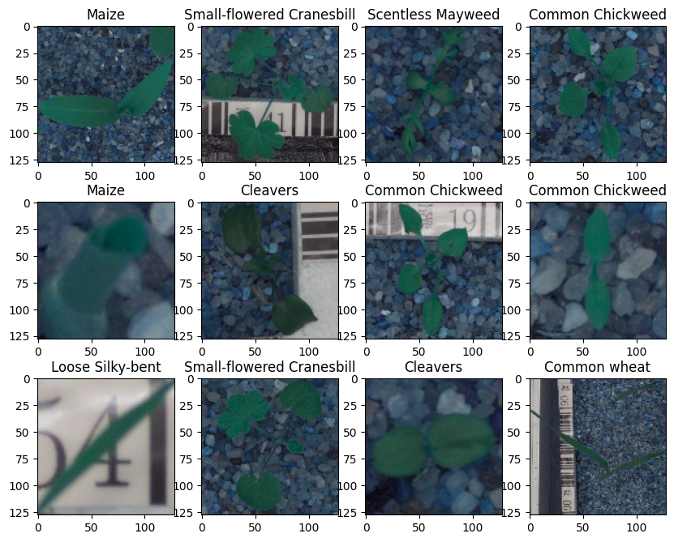

```python
# Plotting the images with their labels

plot_images(images,labels)
```

### Checking the distribution of the target variable

[output not shown]

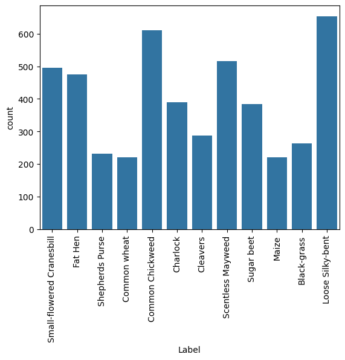

```python
# Checking for data imbalance

sns.countplot(x=labels['Label'])
plt.xticks(rotation='vertical')
```

**Observations:**

## Data Pre-Processing

### Convert the BGR images to RGB images.

```python
# Converting the images from BGR to RGB using cvtColor function of OpenCV

for i in range(len(images)):
  images[i] = cv2.cvtColor(images[i], cv2.COLOR_BGR2RGB)
```

### Resize the images

As the size of the images is large, it may be computationally expensive to train on these larger images; therefore, it is preferable to reduce the image size from 128 to 64.

```python
images_decreased=[]
height = 64
width =  64
dimensions = (width, height)
for i in range(len(images)):
  images_decreased.append( cv2.resize(images[i], dimensions, interpolation=cv2.INTER_LINEAR))
```

**Image before resizing**

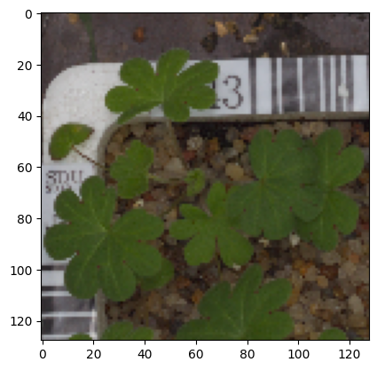

```python
plt.imshow(images[3])
```

**Image after resizing**

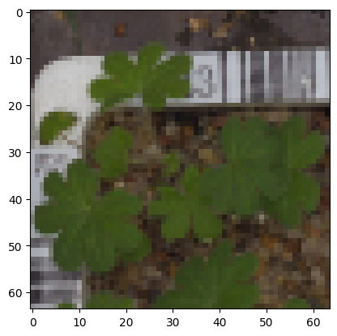

```python
plt.imshow(images_decreased[3])
```

### Data Preparation for Modeling

- Before you proceed to build a model, you need to split the data into train, test, and validation to be able to evaluate the model that you build on the train data
- You'll have to encode categorical features and scale the pixel values.
- You will build a model using the train data and then check its performance

**Split the dataset**

- As we have less images in our dataset, we will only use 10% of our data for testing, 10% of our data for validation and 80% of our data for training.
- Using the train_test_split() function from scikit-learn. Here, we are spliting the dataset into three parts, train, test and validation.

```python
X_temp, X_test, y_temp, y_test = train_test_split(np.array(images_decreased), labels, test_size=0.1, random_state=42,stratify=labels)
X_train, X_val, y_train, y_val = train_test_split(X_temp, y_temp, test_size=0.1, random_state=42,stratify=y_temp)
```

```python
# Checking the shape of train, validation and test data

print(X_train.shape,y_train.shape)
print(X_val.shape,y_val.shape)
print(X_test.shape,y_test.shape)
```

```
(3847, 64, 64, 3) (3847, 1)
(428, 64, 64, 3) (428, 1)
(475, 64, 64, 3) (475, 1)
```

### Encode the target labels

```python
# Converting labels from names to one hot vectors using Labelbinarizer

from sklearn.preprocessing import LabelBinarizer

enc = LabelBinarizer()
y_train_encoded = enc.fit_transform(y_train)
y_val_encoded=enc.transform(y_val)
y_test_encoded=enc.transform(y_test)
```

```python
# Checking the shape of train, validation and test data

y_train_encoded.shape,y_val_encoded.shape,y_test_encoded.shape
```

```
((3847, 12), (428, 12), (475, 12))
```

### Data Normalization

Since the **image pixel values range from 0-255**, our method of normalization here will be **scaling** - we shall **divide all the pixel values by 255 to standardize the images to have values between 0-1.**

```python
# Normalizing the image pixels of train, test and validation data

X_train_normalized = X_train.astype('float32')/255.0
X_val_normalized = X_val.astype('float32')/255.0
X_test_normalized = X_test.astype('float32')/255.0
```

## Model Building

```python
# Clearing backend
backend.clear_session()
```

```python
# Fixing the seed for random number generators

np.random.seed(42)
random.seed(42)
tf.random.set_seed(42)
```

```python
# Intializing a sequential model
model1 = Sequential()

# Adding the first convolutional layer with 128 filters and kernel size 3x3
model1.add(Conv2D(128, (3, 3), activation='relu', padding="same", input_shape=(64, 64, 3)))

# Adding max pooling to reduce the size of the output of the first convolutional layer
model1.add(MaxPooling2D((2, 2), padding='same'))

# Creating two similar convolution and max-pooling layers with activation = relu
model1.add(Conv2D(64, (3, 3), activation='relu', padding="same"))
model1.add(MaxPooling2D((2, 2), padding='same'))

model1.add(Conv2D(32, (3, 3), activation='relu', padding="same"))
model1.add(MaxPooling2D((2, 2), padding='same'))

# Flattening the output of the convolutional layer after max pooling
model1.add(Flatten())

# Adding a fully connected dense layer with 16 neurons
model1.add(Dense(16, activation='relu'))
model1.add(Dropout(0.3))

# Adding the output layer with 12 neurons and activation function as softmax
model1.add(Dense(12, activation='softmax'))

# Using the Adam optimizer
opt = Adam()

# Compiling the model using a suitable metric for the loss function
model1.compile(optimizer=opt, loss='categorical_crossentropy', metrics=['accuracy'])

# Generating the summary of the model
model1.summary()
```

```
Model: "sequential"
```

```
┏━━━━━━━━━━━━━━━━━━━━━━━━━━━━━━━━━━━━━━┳━━━━━━━━━━━━━━━━━━━━━━━━━━━━━┳━━━━━━━━━━━━━━━━━┓
┃ Layer (type)                         ┃ Output Shape                ┃         Param # ┃
┡━━━━━━━━━━━━━━━━━━━━━━━━━━━━━━━━━━━━━━╇━━━━━━━━━━━━━━━━━━━━━━━━━━━━━╇━━━━━━━━━━━━━━━━━┩
│ conv2d (Conv2D)                      │ (None, 64, 64, 128)         │           3,584 │
├──────────────────────────────────────┼─────────────────────────────┼─────────────────┤
│ max_pooling2d (MaxPooling2D)         │ (None, 32, 32, 128)         │               0 │
├──────────────────────────────────────┼─────────────────────────────┼─────────────────┤
│ conv2d_1 (Conv2D)                    │ (None, 32, 32, 64)          │          73,792 │
├──────────────────────────────────────┼─────────────────────────────┼─────────────────┤
│ max_pooling2d_1 (MaxPooling2D)       │ (None, 16, 16, 64)          │               0 │
├──────────────────────────────────────┼─────────────────────────────┼─────────────────┤
│ conv2d_2 (Conv2D)                    │ (None, 16, 16, 32)          │          18,464 │
├──────────────────────────────────────┼─────────────────────────────┼─────────────────┤
│ max_pooling2d_2 (MaxPooling2D)       │ (None, 8, 8, 32)            │               0 │
├──────────────────────────────────────┼─────────────────────────────┼─────────────────┤
│ flatten (Flatten)                    │ (None, 2048)                │               0 │
├──────────────────────────────────────┼─────────────────────────────┼─────────────────┤
│ dense (Dense)                        │ (None, 16)                  │          32,784 │
├──────────────────────────────────────┼─────────────────────────────┼─────────────────┤
│ dropout (Dropout)                    │ (None, 16)                  │               0 │
├──────────────────────────────────────┼─────────────────────────────┼─────────────────┤
│ dense_1 (Dense)                      │ (None, 12)                  │             204 │
└──────────────────────────────────────┴─────────────────────────────┴─────────────────┘
```

```
 Total params: 128,828 (503.23 KB)
```

```
 Trainable params: 128,828 (503.23 KB)
```

```
 Non-trainable params: 0 (0.00 B)
```

**Fitting the model on the train data**

```python
# Complete the code to fit the model on train and also using the validation data for validation
history_1 = model1.fit(
            X_train_normalized, y_train_encoded,
            epochs=30,
            validation_data=(X_val_normalized,y_val_encoded),
            batch_size=32,
            verbose=2
)
```

```
121/121 - 12s - 96ms/step - accuracy: 0.1115 - loss: 2.4620 - val_accuracy: 0.0911 - val_loss: 2.4224
121/121 - 1s - 9ms/step - accuracy: 0.2150 - loss: 2.2420 - val_accuracy: 0.3435 - val_loss: 1.9744
121/121 - 1s - 10ms/step - accuracy: 0.3158 - loss: 1.9998 - val_accuracy: 0.3458 - val_loss: 1.9120
121/121 - 1s - 9ms/step - accuracy: 0.3312 - loss: 1.9050 - val_accuracy: 0.3621 - val_loss: 1.7758
121/121 - 1s - 9ms/step - accuracy: 0.3387 - loss: 1.8466 - val_accuracy: 0.3762 - val_loss: 1.6886
121/121 - 1s - 9ms/step - accuracy: 0.3434 - loss: 1.8080 - val_accuracy: 0.3832 - val_loss: 1.6101
121/121 - 1s - 9ms/step - accuracy: 0.3431 - loss: 1.7656 - val_accuracy: 0.4019 - val_loss: 1.5297
121/121 - 1s - 9ms/step - accuracy: 0.3561 - loss: 1.7384 - val_accuracy: 0.4042 - val_loss: 1.5628
121/121 - 1s - 10ms/step - accuracy: 0.3551 - loss: 1.7119 - val_accuracy: 0.4159 - val_loss: 1.4499
121/121 - 1s - 10ms/step - accuracy: 0.3605 - loss: 1.6903 - val_accuracy: 0.4322 - val_loss: 1.4691
121/121 - 1s - 9ms/step - accuracy: 0.3704 - loss: 1.6442 - val_accuracy: 0.4883 - val_loss: 1.3942
121/121 - 1s - 10ms/step - accuracy: 0.3982 - loss: 1.6064 - val_accuracy: 0.5140 - val_loss: 1.4592
121/121 - 1s - 11ms/step - accuracy: 0.4224 - loss: 1.5464 - val_accuracy: 0.5140 - val_loss: 1.4184
121/121 - 1s - 10ms/step - accuracy: 0.4562 - loss: 1.5069 - val_accuracy: 0.5421 - val_loss: 1.3380
121/121 - 1s - 10ms/step - accuracy: 0.4539 - loss: 1.4872 - val_accuracy: 0.5374 - val_loss: 1.3135
121/121 - 1s - 9ms/step - accuracy: 0.4845 - loss: 1.3959 - val_accuracy: 0.5070 - val_loss: 1.4555
121/121 - 1s - 10ms/step - accuracy: 0.4981 - loss: 1.3426 - val_accuracy: 0.5818 - val_loss: 1.2924
121/121 - 1s - 9ms/step - accuracy: 0.5282 - loss: 1.2964 - val_accuracy: 0.6262 - val_loss: 1.1645
121/121 - 1s - 10ms/step - accuracy: 0.5435 - loss: 1.2376 - val_accuracy: 0.6192 - val_loss: 1.1725
121/121 - 1s - 9ms/step - accuracy: 0.5636 - loss: 1.2049 - val_accuracy: 0.6355 - val_loss: 1.1646
121/121 - 1s - 10ms/step - accuracy: 0.5773 - loss: 1.1803 - val_accuracy: 0.6005 - val_loss: 1.2992
121/121 - 1s - 10ms/step - accuracy: 0.5758 - loss: 1.1822 - val_accuracy: 0.6565 - val_loss: 1.0437
121/121 - 1s - 10ms/step - accuracy: 0.5768 - loss: 1.1535 - val_accuracy: 0.6589 - val_loss: 1.0481
121/121 - 1s - 11ms/step - accuracy: 0.5973 - loss: 1.1058 - val_accuracy: 0.6893 - val_loss: 1.0205
121/121 - 1s - 10ms/step - accuracy: 0.6119 - loss: 1.0940 - val_accuracy: 0.6822 - val_loss: 1.0136
121/121 - 1s - 11ms/step - accuracy: 0.6153 - loss: 1.0409 - val_accuracy: 0.6589 - val_loss: 1.0481
121/121 - 1s - 9ms/step - accuracy: 0.6106 - loss: 1.0902 - val_accuracy: 0.7033 - val_loss: 1.0139
121/121 - 1s - 10ms/step - accuracy: 0.6275 - loss: 1.0350 - val_accuracy: 0.6565 - val_loss: 1.1625
121/121 - 1s - 10ms/step - accuracy: 0.6293 - loss: 1.0167 - val_accuracy: 0.7150 - val_loss: 1.0019
121/121 - 1s - 10ms/step - accuracy: 0.6418 - loss: 0.9833 - val_accuracy: 0.6729 - val_loss: 1.1531
```

**Model Evaluation**

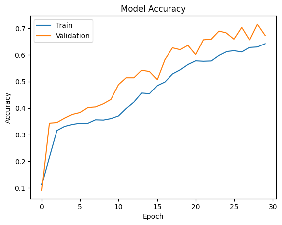

```python
plt.plot(history_1.history['accuracy'])
plt.plot(history_1.history['val_accuracy'])
plt.title('Model Accuracy')
plt.ylabel('Accuracy')
plt.xlabel('Epoch')
plt.legend(['Train', 'Validation'], loc='upper left')
plt.show()
```

**Evaluate the model on test data**

```python
accuracy = model1.evaluate(X_test_normalized, y_test_encoded, verbose=2)
```

```
15/15 - 1s - 72ms/step - accuracy: 0.6653 - loss: 1.1621
```

**Plotting the Confusion Matrix**

```python
# Here we would get the output as probablities for each category

y_pred=model1.predict(X_test_normalized)
```

```
15/15 ━━━━━━━━━━━━━━━━━━━━ 1s 29ms/step
```

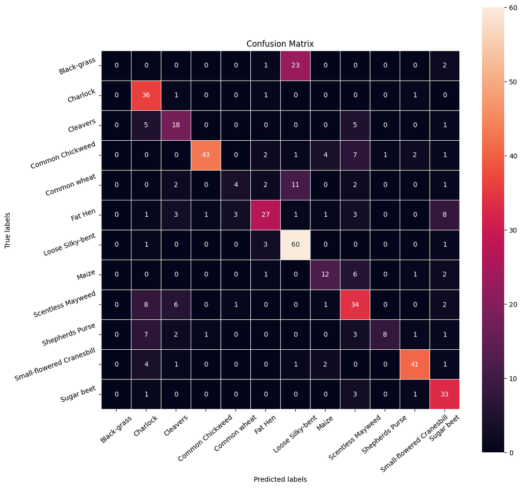

```python
# Obtaining the categorical values from y_test_encoded and y_pred
y_pred_arg=np.argmax(y_pred,axis=1)
y_test_arg=np.argmax(y_test_encoded,axis=1)

# Plotting the Confusion Matrix using confusion matrix() function which is also predefined in tensorflow module
confusion_matrix = tf.math.confusion_matrix(y_test_arg,y_pred_arg)
f, ax = plt.subplots(figsize=(12, 12))
sns.heatmap(
    confusion_matrix,
    annot=True,
    linewidths=.4,
    fmt="d",
    square=True,
    ax=ax
)
# Setting the labels to both the axes
ax.set_xlabel('Predicted labels');ax.set_ylabel('True labels');
ax.set_title('Confusion Matrix');
ax.xaxis.set_ticklabels(list(enc.classes_),rotation=40)
ax.yaxis.set_ticklabels(list(enc.classes_),rotation=20)
plt.show()
```

**Plotting Classification Report**

```python
# Plotting the classification report

from sklearn import metrics
cr=metrics.classification_report(y_test_arg,y_pred_arg)
print(cr)
```

```
              precision    recall  f1-score   support

           0       0.00      0.00      0.00        26
           1       0.57      0.92      0.71        39
           2       0.55      0.62      0.58        29
           3       0.96      0.70      0.81        61
           4       0.50      0.18      0.27        22
           5       0.73      0.56      0.64        48
           6       0.62      0.92      0.74        65
           7       0.60      0.55      0.57        22
           8       0.54      0.65      0.59        52
           9       0.89      0.35      0.50        23
          10       0.87      0.82      0.85        50
          11       0.62      0.87      0.73        38

    accuracy                           0.67       475
   macro avg       0.62      0.60      0.58       475
weighted avg       0.66      0.67      0.64       475
```

**Observations:**

## Model Performance Improvement

**Reducing the Learning Rate:**

**Hint**: Use **ReduceLRonPlateau()** function that will be used to decrease the learning rate by some factor, if the loss is not decreasing for some time. This may start decreasing the loss at a smaller learning rate. There is a possibility that the loss may still not decrease. This may lead to executing the learning rate reduction again in an attempt to achieve a lower loss.

```python
# Code to monitor val_accuracy
learning_rate_reduction = ReduceLROnPlateau(monitor='val_accuracy',
                                            patience=3,
                                            verbose=1,
                                            factor=0.5,
                                            min_lr=0.00001)
```

### **Data Augmentation**

Remember, **data augmentation should not be used in the validation/test data set**.

```python
# Clearing backend
from tensorflow.keras import backend
backend.clear_session()

# Fixing the seed for random number generators
import random
np.random.seed(42)
random.seed(42)
tf.random.set_seed(42)
```

```python
# Setting the rotation_range to 20
train_datagen = ImageDataGenerator(
                              rotation_range=20,
                              fill_mode='nearest'
                              )
```

```python
# Intializing a sequential model
model2 = Sequential()

# Adding the first convolutional layer with 64 filters and kernel size 3x3 and using 'same' padding
model2.add(Conv2D(64, (3, 3), activation='relu', padding="same", input_shape=(64, 64, 3)))

# Adding max pooling to reduce the size of the output of the first convolutional layer
model2.add(MaxPooling2D((2, 2), padding='same'))


# Adding a second convolutional layer and max pooling, followed by batch normalization
model2.add(Conv2D(32, (3, 3), activation='relu', padding="same"))
model2.add(MaxPooling2D((2, 2), padding='same'))
model2.add(BatchNormalization())

# Flattening the output of the convolutional layers after max pooling
model2.add(Flatten())

# Adding a fully connected dense layer with 16 neurons
model2.add(Dense(16, activation='relu'))

# Adding dropout with a dropout rate of 0.3
model2.add(Dropout(0.3))

# Adding the output layer with 12 neurons and activation function as softmax
model2.add(Dense(12, activation='softmax'))

# Initializing Adam optimizer
opt = Adam()

# Compiling the model
model2.compile(optimizer=opt, loss='categorical_crossentropy', metrics=['accuracy'])

# Generate the summary of the model
model2.summary()
```

```
Model: "sequential"
```

```
┏━━━━━━━━━━━━━━━━━━━━━━━━━━━━━━━━━━━━━━┳━━━━━━━━━━━━━━━━━━━━━━━━━━━━━┳━━━━━━━━━━━━━━━━━┓
┃ Layer (type)                         ┃ Output Shape                ┃         Param # ┃
┡━━━━━━━━━━━━━━━━━━━━━━━━━━━━━━━━━━━━━━╇━━━━━━━━━━━━━━━━━━━━━━━━━━━━━╇━━━━━━━━━━━━━━━━━┩
│ conv2d (Conv2D)                      │ (None, 64, 64, 64)          │           1,792 │
├──────────────────────────────────────┼─────────────────────────────┼─────────────────┤
│ max_pooling2d (MaxPooling2D)         │ (None, 32, 32, 64)          │               0 │
├──────────────────────────────────────┼─────────────────────────────┼─────────────────┤
│ conv2d_1 (Conv2D)                    │ (None, 32, 32, 32)          │          18,464 │
├──────────────────────────────────────┼─────────────────────────────┼─────────────────┤
│ max_pooling2d_1 (MaxPooling2D)       │ (None, 16, 16, 32)          │               0 │
├──────────────────────────────────────┼─────────────────────────────┼─────────────────┤
│ batch_normalization                  │ (None, 16, 16, 32)          │             128 │
│ (BatchNormalization)                 │                             │                 │
├──────────────────────────────────────┼─────────────────────────────┼─────────────────┤
│ flatten (Flatten)                    │ (None, 8192)                │               0 │
├──────────────────────────────────────┼─────────────────────────────┼─────────────────┤
│ dense (Dense)                        │ (None, 16)                  │         131,088 │
├──────────────────────────────────────┼─────────────────────────────┼─────────────────┤
│ dropout (Dropout)                    │ (None, 16)                  │               0 │
├──────────────────────────────────────┼─────────────────────────────┼─────────────────┤
│ dense_1 (Dense)                      │ (None, 12)                  │             204 │
└──────────────────────────────────────┴─────────────────────────────┴─────────────────┘
```

```
 Total params: 151,676 (592.48 KB)
```

```
 Trainable params: 151,612 (592.23 KB)
```

```
 Non-trainable params: 64 (256.00 B)
```

**Fitting the model on the train data**

```python
# Fitting the model on training data with batch_size=64 and epochs=25

epochs = 25
batch_size = 64

history = model2.fit(train_datagen.flow(X_train_normalized,y_train_encoded,
                                       batch_size=batch_size,
                                       shuffle=False),
                                       epochs=epochs,
                                       steps_per_epoch=X_train_normalized.shape[0] // batch_size,
                                       validation_data=(X_val_normalized,y_val_encoded),
                                       verbose=1,callbacks=[learning_rate_reduction])
```

```
60/60 ━━━━━━━━━━━━━━━━━━━━ 14s 149ms/step - accuracy: 0.1637 - loss: 2.4052 - val_accuracy: 0.2360 - val_loss: 2.4103 - learning_rate: 0.0010
60/60 ━━━━━━━━━━━━━━━━━━━━ 0s 982us/step - accuracy: 0.3125 - loss: 2.0082 - val_accuracy: 0.2710 - val_loss: 2.4128 - learning_rate: 0.0010
60/60 ━━━━━━━━━━━━━━━━━━━━ 14s 83ms/step - accuracy: 0.3816 - loss: 1.8296 - val_accuracy: 0.4229 - val_loss: 2.2817 - learning_rate: 0.0010
60/60 ━━━━━━━━━━━━━━━━━━━━ 0s 1ms/step - accuracy: 0.4688 - loss: 1.5539 - val_accuracy: 0.4136 - val_loss: 2.2760 - learning_rate: 0.0010
60/60 ━━━━━━━━━━━━━━━━━━━━ 4s 64ms/step - accuracy: 0.4615 - loss: 1.6398 - val_accuracy: 0.4579 - val_loss: 2.2109 - learning_rate: 0.0010
60/60 ━━━━━━━━━━━━━━━━━━━━ 0s 1ms/step - accuracy: 0.4219 - loss: 1.6609 - val_accuracy: 0.4579 - val_loss: 2.2029 - learning_rate: 0.0010
60/60 ━━━━━━━━━━━━━━━━━━━━ 5s 73ms/step - accuracy: 0.4956 - loss: 1.5209 - val_accuracy: 0.5397 - val_loss: 2.0722 - learning_rate: 0.0010
60/60 ━━━━━━━━━━━━━━━━━━━━ 0s 2ms/step - accuracy: 0.5312 - loss: 1.4984 - val_accuracy: 0.5234 - val_loss: 2.0830 - learning_rate: 0.0010
60/60 ━━━━━━━━━━━━━━━━━━━━ 5s 73ms/step - accuracy: 0.5392 - loss: 1.3303 - val_accuracy: 0.3505 - val_loss: 1.8786 - learning_rate: 0.0010
 1/60 ━━━━━━━━━━━━━━━━━━━━ 0s 14ms/step - accuracy: 0.6250 - loss: 1.1348
Epoch 10: ReduceLROnPlateau reducing learning rate to 0.0005000000237487257.
60/60 ━━━━━━━━━━━━━━━━━━━━ 0s 1ms/step - accuracy: 0.6250 - loss: 1.1348 - val_accuracy: 0.3411 - val_loss: 1.8820 - learning_rate: 0.0010
60/60 ━━━━━━━━━━━━━━━━━━━━ 10s 82ms/step - accuracy: 0.5555 - loss: 1.2725 - val_accuracy: 0.6051 - val_loss: 1.7811 - learning_rate: 5.0000e-04
60/60 ━━━━━━━━━━━━━━━━━━━━ 0s 1ms/step - accuracy: 0.5312 - loss: 1.2955 - val_accuracy: 0.6238 - val_loss: 1.7630 - learning_rate: 5.0000e-04
60/60 ━━━━━━━━━━━━━━━━━━━━ 5s 63ms/step - accuracy: 0.5780 - loss: 1.2271 - val_accuracy: 0.6565 - val_loss: 1.5010 - learning_rate: 5.0000e-04
60/60 ━━━━━━━━━━━━━━━━━━━━ 0s 1ms/step - accuracy: 0.5781 - loss: 1.4715 - val_accuracy: 0.6589 - val_loss: 1.4884 - learning_rate: 5.0000e-04
60/60 ━━━━━━━━━━━━━━━━━━━━ 4s 62ms/step - accuracy: 0.5965 - loss: 1.1867 - val_accuracy: 0.6846 - val_loss: 1.3799 - learning_rate: 5.0000e-04
60/60 ━━━━━━━━━━━━━━━━━━━━ 0s 1ms/step - accuracy: 0.7031 - loss: 0.9384 - val_accuracy: 0.6869 - val_loss: 1.3766 - learning_rate: 5.0000e-04
60/60 ━━━━━━━━━━━━━━━━━━━━ 5s 84ms/step - accuracy: 0.5999 - loss: 1.1499 - val_accuracy: 0.6495 - val_loss: 1.2911 - learning_rate: 5.0000e-04
60/60 ━━━━━━━━━━━━━━━━━━━━ 0s 1ms/step - accuracy: 0.6875 - loss: 0.9286 - val_accuracy: 0.6495 - val_loss: 1.3002 - learning_rate: 5.0000e-04
60/60 ━━━━━━━━━━━━━━━━━━━━ 9s 62ms/step - accuracy: 0.6111 - loss: 1.1372 - val_accuracy: 0.6916 - val_loss: 1.0582 - learning_rate: 5.0000e-04
60/60 ━━━━━━━━━━━━━━━━━━━━ 0s 996us/step - accuracy: 0.6250 - loss: 1.1984 - val_accuracy: 0.6822 - val_loss: 1.0401 - learning_rate: 5.0000e-04
60/60 ━━━━━━━━━━━━━━━━━━━━ 7s 92ms/step - accuracy: 0.6207 - loss: 1.0595 - val_accuracy: 0.6659 - val_loss: 1.0563 - learning_rate: 5.0000e-04
 1/60 ━━━━━━━━━━━━━━━━━━━━ 0s 14ms/step - accuracy: 0.7031 - loss: 0.8832
Epoch 22: ReduceLROnPlateau reducing learning rate to 0.0002500000118743628.
60/60 ━━━━━━━━━━━━━━━━━━━━ 0s 1ms/step - accuracy: 0.7031 - loss: 0.8832 - val_accuracy: 0.6495 - val_loss: 1.1079 - learning_rate: 5.0000e-04
60/60 ━━━━━━━━━━━━━━━━━━━━ 5s 81ms/step - accuracy: 0.6433 - loss: 1.0411 - val_accuracy: 0.7150 - val_loss: 0.9171 - learning_rate: 2.5000e-04
60/60 ━━━━━━━━━━━━━━━━━━━━ 0s 2ms/step - accuracy: 0.7656 - loss: 0.7934 - val_accuracy: 0.7150 - val_loss: 0.9217 - learning_rate: 2.5000e-04
60/60 ━━━━━━━━━━━━━━━━━━━━ 6s 82ms/step - accuracy: 0.6372 - loss: 1.0139 - val_accuracy: 0.6869 - val_loss: 0.9332 - learning_rate: 2.5000e-04
```

**Model Evaluation**

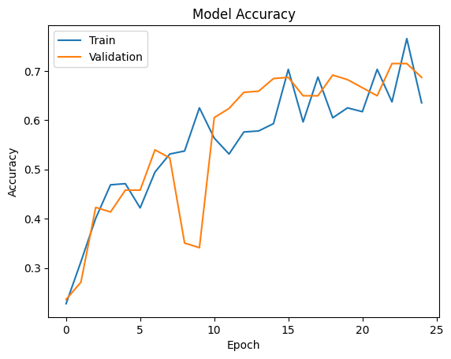

```python
plt.plot(history.history['accuracy'])
plt.plot(history.history['val_accuracy'])
plt.title('Model Accuracy')
plt.ylabel('Accuracy')
plt.xlabel('Epoch')
plt.legend(['Train', 'Validation'], loc='upper left')
plt.show()
```

**Evaluate the model on test data**

```python
accuracy = model2.evaluate(X_test_normalized, y_test_encoded, verbose=2)
```

```
15/15 - 1s - 72ms/step - accuracy: 0.6779 - loss: 0.9985
```

**Plotting the Confusion Matrix**

```python
# To obtain the output probabilities
y_pred=model2.predict(X_test_normalized)
```

```
15/15 ━━━━━━━━━━━━━━━━━━━━ 1s 20ms/step
```

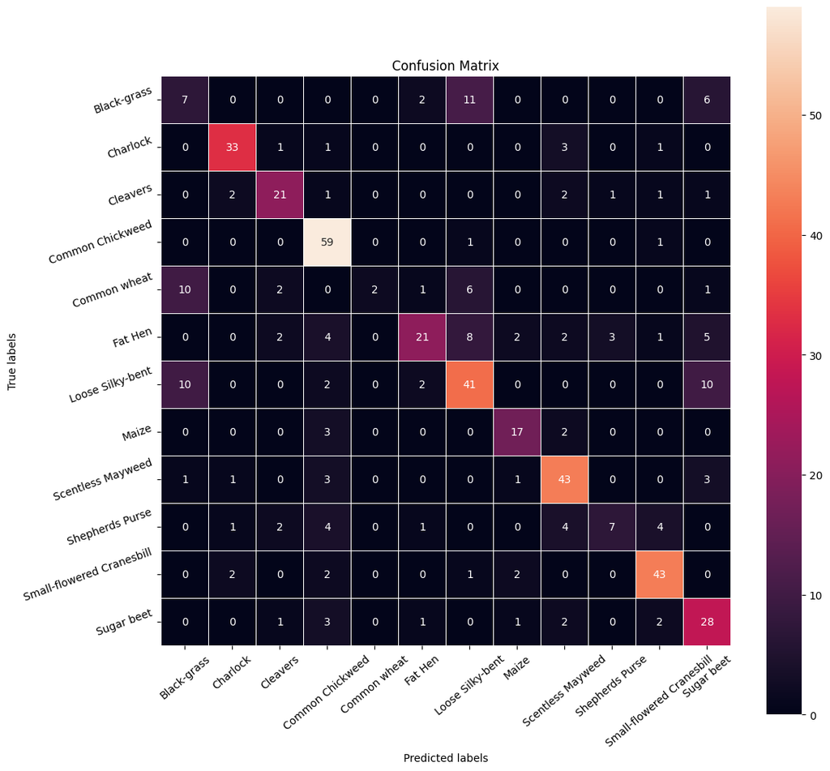

```python
# Obtaining the categorical values from y_test_encoded and y_pred
y_pred_arg=np.argmax(y_pred,axis=1)
y_test_arg=np.argmax(y_test_encoded,axis=1)

# Plotting the Confusion Matrix using confusion matrix() function which is also predefined in tensorflow module
confusion_matrix = tf.math.confusion_matrix(y_test_arg,y_pred_arg)
f, ax = plt.subplots(figsize=(12, 12))
sns.heatmap(
    confusion_matrix,
    annot=True,
    linewidths=.4,
    fmt="d",
    square=True,
    ax=ax
)
# Setting the labels to both the axes
ax.set_xlabel('Predicted labels');ax.set_ylabel('True labels');
ax.set_title('Confusion Matrix');
ax.xaxis.set_ticklabels(list(enc.classes_),rotation=40)
ax.yaxis.set_ticklabels(list(enc.classes_),rotation=20)
plt.show()
```

**Plotting Classification Report**

```python
# Plotting the classification report

from sklearn.metrics import classification_report
cr=classification_report(y_test_arg,y_pred_arg)
print(cr)
```

```
              precision    recall  f1-score   support

           0       0.25      0.27      0.26        26
           1       0.85      0.85      0.85        39
           2       0.72      0.72      0.72        29
           3       0.72      0.97      0.83        61
           4       1.00      0.09      0.17        22
           5       0.75      0.44      0.55        48
           6       0.60      0.63      0.62        65
           7       0.74      0.77      0.76        22
           8       0.74      0.83      0.78        52
           9       0.64      0.30      0.41        23
          10       0.81      0.86      0.83        50
          11       0.52      0.74      0.61        38

    accuracy                           0.68       475
   macro avg       0.69      0.62      0.62       475
weighted avg       0.70      0.68      0.66       475
```

**Observations:**

To enhance performance further, leveraging the **VGG16** pre-trained model via transfer learning or fine-tuning is recommended. VGG16’s deep architecture and ability to extract complex features can improve generalization, particularly for challenging classes.

While Model2 is superior to Model1, incorporating **VGG16** or hybrid approaches can potentially deliver significant performance gains, particularly for underrepresented and hard-to-classify categories.

## Transfer Learning using VGG16

- Let's try again, but this time, we will be using the idea of **Transfer Learning**. We will be loading a pre-built architecture - **VGG16**, which was trained on the ImageNet dataset and is the runner-up in the ImageNet competition in 2014.
- For training VGG16, we will directly use the convolutional and pooling layers and freeze their weights i.e. no training will be done on them. For classification, we will replace the existing fully-connected layers with FC layers created specifically for our problem.

```python
from tensorflow.keras.models import Model
from keras.applications.vgg16 import VGG16

vgg_model = VGG16(weights='imagenet', include_top = False, input_shape = (64,64,3))
vgg_model.summary()
```

```
Downloading data from https://storage.googleapis.com/tensorflow/keras-applications/vgg16/vgg16_weights_tf_dim_ordering_tf_kernels_notop.h5
58889256/58889256 ━━━━━━━━━━━━━━━━━━━━ 0s 0us/step
```

```
Model: "vgg16"
```

```
┏━━━━━━━━━━━━━━━━━━━━━━━━━━━━━━━━━━━━━━┳━━━━━━━━━━━━━━━━━━━━━━━━━━━━━┳━━━━━━━━━━━━━━━━━┓
┃ Layer (type)                         ┃ Output Shape                ┃         Param # ┃
┡━━━━━━━━━━━━━━━━━━━━━━━━━━━━━━━━━━━━━━╇━━━━━━━━━━━━━━━━━━━━━━━━━━━━━╇━━━━━━━━━━━━━━━━━┩
│ input_layer_1 (InputLayer)           │ (None, 64, 64, 3)           │               0 │
├──────────────────────────────────────┼─────────────────────────────┼─────────────────┤
│ block1_conv1 (Conv2D)                │ (None, 64, 64, 64)          │           1,792 │
├──────────────────────────────────────┼─────────────────────────────┼─────────────────┤
│ block1_conv2 (Conv2D)                │ (None, 64, 64, 64)          │          36,928 │
├──────────────────────────────────────┼─────────────────────────────┼─────────────────┤
│ block1_pool (MaxPooling2D)           │ (None, 32, 32, 64)          │               0 │
├──────────────────────────────────────┼─────────────────────────────┼─────────────────┤
│ block2_conv1 (Conv2D)                │ (None, 32, 32, 128)         │          73,856 │
├──────────────────────────────────────┼─────────────────────────────┼─────────────────┤
│ block2_conv2 (Conv2D)                │ (None, 32, 32, 128)         │         147,584 │
├──────────────────────────────────────┼─────────────────────────────┼─────────────────┤
│ block2_pool (MaxPooling2D)           │ (None, 16, 16, 128)         │               0 │
├──────────────────────────────────────┼─────────────────────────────┼─────────────────┤
│ block3_conv1 (Conv2D)                │ (None, 16, 16, 256)         │         295,168 │
├──────────────────────────────────────┼─────────────────────────────┼─────────────────┤
│ block3_conv2 (Conv2D)                │ (None, 16, 16, 256)         │         590,080 │
├──────────────────────────────────────┼─────────────────────────────┼─────────────────┤
│ block3_conv3 (Conv2D)                │ (None, 16, 16, 256)         │         590,080 │
├──────────────────────────────────────┼─────────────────────────────┼─────────────────┤
│ block3_pool (MaxPooling2D)           │ (None, 8, 8, 256)           │               0 │
├──────────────────────────────────────┼─────────────────────────────┼─────────────────┤
│ block4_conv1 (Conv2D)                │ (None, 8, 8, 512)           │       1,180,160 │
├──────────────────────────────────────┼─────────────────────────────┼─────────────────┤
│ block4_conv2 (Conv2D)                │ (None, 8, 8, 512)           │       2,359,808 │
├──────────────────────────────────────┼─────────────────────────────┼─────────────────┤
│ block4_conv3 (Conv2D)                │ (None, 8, 8, 512)           │       2,359,808 │
├──────────────────────────────────────┼─────────────────────────────┼─────────────────┤
│ block4_pool (MaxPooling2D)           │ (None, 4, 4, 512)           │               0 │
├──────────────────────────────────────┼─────────────────────────────┼─────────────────┤
│ block5_conv1 (Conv2D)                │ (None, 4, 4, 512)           │       2,359,808 │
├──────────────────────────────────────┼─────────────────────────────┼─────────────────┤
│ block5_conv2 (Conv2D)                │ (None, 4, 4, 512)           │       2,359,808 │
├──────────────────────────────────────┼─────────────────────────────┼─────────────────┤
│ block5_conv3 (Conv2D)                │ (None, 4, 4, 512)           │       2,359,808 │
├──────────────────────────────────────┼─────────────────────────────┼─────────────────┤
│ block5_pool (MaxPooling2D)           │ (None, 2, 2, 512)           │               0 │
└──────────────────────────────────────┴─────────────────────────────┴─────────────────┘
```

```
 Total params: 14,714,688 (56.13 MB)
```

```
 Trainable params: 14,714,688 (56.13 MB)
```

```
 Non-trainable params: 0 (0.00 B)
```

```python
# Making all the layers of the VGG model non-trainable. i.e. freezing them
for layer in vgg_model.layers:
    layer.trainable = False
```

```python
new_model = Sequential()

# Adding the convolutional part of the VGG16 model from above
new_model.add(vgg_model)

# Flattening the output of the VGG16 model because it is from a convolutional layer
new_model.add(Flatten())

# Adding a dense output layer
new_model.add(Dense(32, activation='relu'))
new_model.add(Dropout(0.2))
new_model.add(Dense(16, activation='relu'))
new_model.add(Dense(12, activation='softmax'))
opt=Adam()

# Compile model
new_model.compile(optimizer=opt, loss='categorical_crossentropy', metrics=['accuracy'])

# Generating the summary of the model
new_model.summary()
```

```
Model: "sequential_1"
```

```
┏━━━━━━━━━━━━━━━━━━━━━━━━━━━━━━━━━━━━━━┳━━━━━━━━━━━━━━━━━━━━━━━━━━━━━┳━━━━━━━━━━━━━━━━━┓
┃ Layer (type)                         ┃ Output Shape                ┃         Param # ┃
┡━━━━━━━━━━━━━━━━━━━━━━━━━━━━━━━━━━━━━━╇━━━━━━━━━━━━━━━━━━━━━━━━━━━━━╇━━━━━━━━━━━━━━━━━┩
│ vgg16 (Functional)                   │ (None, 2, 2, 512)           │      14,714,688 │
├──────────────────────────────────────┼─────────────────────────────┼─────────────────┤
│ flatten_1 (Flatten)                  │ (None, 2048)                │               0 │
├──────────────────────────────────────┼─────────────────────────────┼─────────────────┤
│ dense_2 (Dense)                      │ (None, 32)                  │          65,568 │
├──────────────────────────────────────┼─────────────────────────────┼─────────────────┤
│ dropout_1 (Dropout)                  │ (None, 32)                  │               0 │
├──────────────────────────────────────┼─────────────────────────────┼─────────────────┤
│ dense_3 (Dense)                      │ (None, 16)                  │             528 │
├──────────────────────────────────────┼─────────────────────────────┼─────────────────┤
│ dense_4 (Dense)                      │ (None, 12)                  │             204 │
└──────────────────────────────────────┴─────────────────────────────┴─────────────────┘
```

```
 Total params: 14,780,988 (56.38 MB)
```

```
 Trainable params: 66,300 (258.98 KB)
```

```
 Non-trainable params: 14,714,688 (56.13 MB)
```

```python
# Epochs
epochs = 25

# Batch size
batch_size = 64

history_vgg16 = new_model.fit(train_datagen.flow(X_train_normalized,y_train_encoded,
                                       batch_size=batch_size,
                                       seed=42,
                                       shuffle=False),
                    epochs=epochs,
                    steps_per_epoch=X_train_normalized.shape[0] // batch_size,
                    validation_data=(X_val_normalized,y_val_encoded),
                    verbose=1)
```

```
60/60 ━━━━━━━━━━━━━━━━━━━━ 32s 439ms/step - accuracy: 0.1682 - loss: 2.4133 - val_accuracy: 0.2780 - val_loss: 2.1543
60/60 ━━━━━━━━━━━━━━━━━━━━ 0s 4ms/step - accuracy: 0.3281 - loss: 2.0936 - val_accuracy: 0.2757 - val_loss: 2.1538
60/60 ━━━━━━━━━━━━━━━━━━━━ 5s 70ms/step - accuracy: 0.2693 - loss: 2.1233 - val_accuracy: 0.3435 - val_loss: 1.9588
60/60 ━━━━━━━━━━━━━━━━━━━━ 0s 6ms/step - accuracy: 0.4375 - loss: 1.8587 - val_accuracy: 0.3411 - val_loss: 1.9589
60/60 ━━━━━━━━━━━━━━━━━━━━ 7s 104ms/step - accuracy: 0.3216 - loss: 1.9221 - val_accuracy: 0.3855 - val_loss: 1.7947
60/60 ━━━━━━━━━━━━━━━━━━━━ 0s 3ms/step - accuracy: 0.3906 - loss: 1.9086 - val_accuracy: 0.3855 - val_loss: 1.7945
60/60 ━━━━━━━━━━━━━━━━━━━━ 8s 75ms/step - accuracy: 0.3983 - loss: 1.7315 - val_accuracy: 0.3902 - val_loss: 1.7279
60/60 ━━━━━━━━━━━━━━━━━━━━ 0s 3ms/step - accuracy: 0.3594 - loss: 1.9015 - val_accuracy: 0.3972 - val_loss: 1.7231
60/60 ━━━━━━━━━━━━━━━━━━━━ 7s 97ms/step - accuracy: 0.4234 - loss: 1.6532 - val_accuracy: 0.4065 - val_loss: 1.6690
60/60 ━━━━━━━━━━━━━━━━━━━━ 0s 6ms/step - accuracy: 0.3750 - loss: 1.6600 - val_accuracy: 0.4229 - val_loss: 1.6555
60/60 ━━━━━━━━━━━━━━━━━━━━ 8s 74ms/step - accuracy: 0.4292 - loss: 1.6052 - val_accuracy: 0.4393 - val_loss: 1.5833
60/60 ━━━━━━━━━━━━━━━━━━━━ 0s 6ms/step - accuracy: 0.5312 - loss: 1.5598 - val_accuracy: 0.4463 - val_loss: 1.5795
60/60 ━━━━━━━━━━━━━━━━━━━━ 10s 74ms/step - accuracy: 0.4647 - loss: 1.5304 - val_accuracy: 0.4509 - val_loss: 1.5331
60/60 ━━━━━━━━━━━━━━━━━━━━ 0s 3ms/step - accuracy: 0.4688 - loss: 1.4872 - val_accuracy: 0.4393 - val_loss: 1.5336
60/60 ━━━━━━━━━━━━━━━━━━━━ 7s 117ms/step - accuracy: 0.4749 - loss: 1.4820 - val_accuracy: 0.4766 - val_loss: 1.4880
60/60 ━━━━━━━━━━━━━━━━━━━━ 0s 3ms/step - accuracy: 0.4531 - loss: 1.4534 - val_accuracy: 0.4860 - val_loss: 1.4877
60/60 ━━━━━━━━━━━━━━━━━━━━ 10s 112ms/step - accuracy: 0.5058 - loss: 1.4126 - val_accuracy: 0.4977 - val_loss: 1.4573
60/60 ━━━━━━━━━━━━━━━━━━━━ 0s 4ms/step - accuracy: 0.4219 - loss: 1.4634 - val_accuracy: 0.4953 - val_loss: 1.4555
60/60 ━━━━━━━━━━━━━━━━━━━━ 6s 87ms/step - accuracy: 0.4965 - loss: 1.3995 - val_accuracy: 0.4860 - val_loss: 1.4338
60/60 ━━━━━━━━━━━━━━━━━━━━ 0s 3ms/step - accuracy: 0.4844 - loss: 1.3830 - val_accuracy: 0.4836 - val_loss: 1.4310
60/60 ━━━━━━━━━━━━━━━━━━━━ 10s 89ms/step - accuracy: 0.5212 - loss: 1.3687 - val_accuracy: 0.5187 - val_loss: 1.4016
60/60 ━━━━━━━━━━━━━━━━━━━━ 0s 6ms/step - accuracy: 0.4688 - loss: 1.5276 - val_accuracy: 0.5187 - val_loss: 1.4025
60/60 ━━━━━━━━━━━━━━━━━━━━ 5s 74ms/step - accuracy: 0.5274 - loss: 1.3114 - val_accuracy: 0.5140 - val_loss: 1.3671
60/60 ━━━━━━━━━━━━━━━━━━━━ 0s 6ms/step - accuracy: 0.4375 - loss: 1.4449 - val_accuracy: 0.5164 - val_loss: 1.3644
60/60 ━━━━━━━━━━━━━━━━━━━━ 5s 70ms/step - accuracy: 0.5405 - loss: 1.2889 - val_accuracy: 0.5117 - val_loss: 1.3711
```

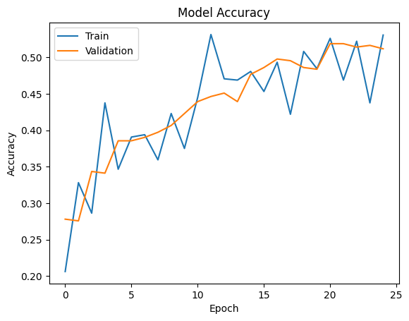

```python
plt.plot(history_vgg16.history['accuracy'])
plt.plot(history_vgg16.history['val_accuracy'])
plt.title('Model Accuracy')
plt.ylabel('Accuracy')
plt.xlabel('Epoch')
plt.legend(['Train', 'Validation'], loc='upper left')
plt.show()
```

```python
accuracy = new_model.evaluate(X_test_normalized, y_test_encoded, verbose=2)
```

```
15/15 - 2s - 162ms/step - accuracy: 0.5368 - loss: 1.3613
```

```python
# Here we would get the output as probablities for each category

y_pred=new_model.predict(X_test_normalized)
```

```
15/15 ━━━━━━━━━━━━━━━━━━━━ 2s 64ms/step
```

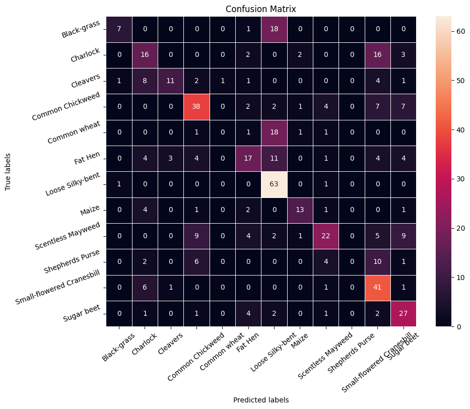

```python
# Obtaining the categorical values from y_test_encoded and y_pred
y_pred_arg=np.argmax(y_pred,axis=1)
y_test_arg=np.argmax(y_test_encoded,axis=1)

# Plotting the Confusion Matrix using confusion matrix() function which is also predefined tensorflow module
confusion_matrix = tf.math.confusion_matrix(y_test_arg,y_pred_arg)
f, ax = plt.subplots(figsize=(10, 8))
sns.heatmap(
    confusion_matrix,
    annot=True,
    linewidths=.4,
    fmt="d",
    square=True,
    ax=ax
)
# Setting the labels to both the axes
ax.set_xlabel('Predicted labels');ax.set_ylabel('True labels');
ax.set_title('Confusion Matrix');
ax.xaxis.set_ticklabels(list(enc.classes_),rotation=40)
ax.yaxis.set_ticklabels(list(enc.classes_),rotation=20)
plt.show()
```

```python
# Plotting the classification report
from sklearn.metrics import classification_report
cr=classification_report(y_test_arg,y_pred_arg)
print(cr)
```

```
              precision    recall  f1-score   support

           0       0.78      0.27      0.40        26
           1       0.39      0.41      0.40        39
           2       0.73      0.38      0.50        29
           3       0.61      0.62      0.62        61
           4       0.00      0.00      0.00        22
           5       0.50      0.35      0.41        48
           6       0.54      0.97      0.70        65
           7       0.72      0.59      0.65        22
           8       0.61      0.42      0.50        52
           9       0.00      0.00      0.00        23
          10       0.46      0.82      0.59        50
          11       0.50      0.71      0.59        38

    accuracy                           0.54       475
   macro avg       0.49      0.46      0.45       475
weighted avg       0.51      0.54      0.50       475
```

**Observations:**

## Final Model

Comment on the final model you have selected and use the same in the below code to visualize the image.

Performance Metrics of Different Models

| Metric | Base CNN Model | CNN Model with Data Augmentation | VGG16 Transfer Learning Model |
| --- | --- | --- | --- |
| Accuracy | 66.53% | 67.79% | 53.68% |
| Loss | 116.21% | 99.85% | 136.13% |
| Macro avg Precision | 62.00% | 69.00% | 49.00% |
| Macro avg Recall | 60.00% | 62.00% | 46.00% |
| Macro avg F1-Score | 58.00% | 62.00% | 45.00% |
| Weighted avg Precision | 66.00% | 70.00% | 51.00% |
| Weighted avg Recall | 67.00% | 68.00% | 54.00% |
| Weighted avg F1-Score | 64.00% | 66.00% | 50.00% |

In summary, **Model2 remains the best performer among the three**, providing a more balanced and reliable classification. While VGG16’s deeper architecture offers potential, it requires better fine-tuning, regularization, or adjustments, such as transfer learning with frozen layers or increased data augmentation, to fully leverage its capabilities and outperform Model2. For now, **Model2 is the most effective choice.**

### Visualizing the prediction

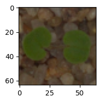

```
1/1 ━━━━━━━━━━━━━━━━━━━━ 0s 420ms/step
Predicted Label ['Small-flowered Cranesbill']
True Label Small-flowered Cranesbill
```

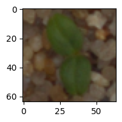

```
1/1 ━━━━━━━━━━━━━━━━━━━━ 0s 16ms/step
Predicted Label ['Cleavers']
True Label Cleavers
```

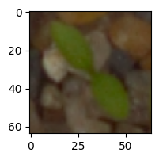

```
1/1 ━━━━━━━━━━━━━━━━━━━━ 0s 16ms/step
Predicted Label ['Common Chickweed']
True Label Common Chickweed
```

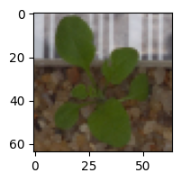

```
1/1 ━━━━━━━━━━━━━━━━━━━━ 0s 16ms/step
Predicted Label ['Shepherds Purse']
True Label Shepherds Purse
```

```python
# Visualizing the predicted and correct label of images from test data

plt.figure(figsize=(2,2))
plt.imshow(X_test[2])
plt.show()
print('Predicted Label', enc.inverse_transform(model2.predict((X_test_normalized[2].reshape(1,64,64,3)))))   # reshaping the input image as we are only trying to predict using a single image
print('True Label', enc.inverse_transform(y_test_encoded)[2])                                               # using inverse_transform() to get the output label from the output vector

plt.figure(figsize=(2,2))
plt.imshow(X_test[33])
plt.show()
print('Predicted Label', enc.inverse_transform(model2.predict((X_test_normalized[33].reshape(1,64,64,3)))))  # reshaping the input image as we are only trying to predict using a single image
print('True Label', enc.inverse_transform(y_test_encoded)[33])                                              # using inverse_transform() to get the output label from the output vector

plt.figure(figsize=(2,2))
plt.imshow(X_test[59],)
plt.show()
print('Predicted Label', enc.inverse_transform(model2.predict((X_test_normalized[59].reshape(1,64,64,3)))))  # reshaping the input image as we are only trying to predict using a single image
print('True Label', enc.inverse_transform(y_test_encoded)[59])                                              # using inverse_transform() to get the output label from the output vector

plt.figure(figsize=(2,2))
plt.imshow(X_test[36])
plt.show()
print('Predicted Label', enc.inverse_transform(model2.predict((X_test_normalized[36].reshape(1,64,64,3)))))  # reshaping the input image as we are only trying to predict using a single image
print('True Label', enc.inverse_transform(y_test_encoded)[36])                                              # using inverse_transform() to get the output label from the output vector
```

## Business Recommendations:

1. Adopt AI-Driven Plant Seedling Classification:
   - Deploy Model2 initially for practical use in sorting plant seedlings due to its strong generalization and superior accuracy. This will immediately reduce the manual workload, improving operational efficiency and freeing up human resources for higher-order tasks.
2. Invest in Data Collection and Annotation:
   - Focus on collecting additional high-quality, diverse, and representative images of underperforming classes (e.g., classes 4 and 9). Partner with agricultural organizations or use drones and IoT devices to gather more training data, ensuring model adaptability to real-world conditions.
3. Integrate AI Models with Existing Agricultural Tools:
   - Combine the AI model with precision agriculture systems to classify seedlings directly in the field. For example, camera-equipped drones or robotic arms can use the model to sort and identify seedlings, allowing farmers to focus on strategic decisions like crop planning and pest control.
4. Focus on Sustainable Agriculture:
   - Leverage AI’s ability to classify seedlings accurately to improve crop yields and reduce manual intervention. Automating seedling identification enables farmers to adopt sustainable practices by optimizing water, fertilizer, and pesticide usage, ultimately improving environmental outcomes.
5. Long-Term Vision for Automation:
   - As the model matures, integrate it into a broader AI-powered ecosystem that includes weed detection, pest identification, and soil health monitoring. This end-to-end solution could significantly modernize agriculture and offer a competitive advantage in this trillion-dollar industry.